# Stat 380 Final Project

Funke Alliyu and Lauryn Pavlik

April 30th, 2019

```r
# Clean up environment
rm(list = ls())
# Load packages
library(tidyverse)
library(readr)
library(utils)
library(dplyr)
library(tidyverse)
library(mdsr)
library(mosaic)
library(stringr)
library(tidytext)
library(janeaustenr)
library(wordcloud)
# Add data
raw_fed_data <-
  read_csv("dif source join.csv")
NCANDS <-
  read_csv("Findings from NCANDS - Data Tables (updated with FY 2015).csv")
# User-defined functions
## circle
circle <- function(center = c(0, 0), npoints = 100) {
    r = 1
    tt = seq(0, 2 * pi, length = npoints)
    xx = center[1] + r * cos(tt)
    yy = center[1] + r * sin(tt)
    return(data.frame(x = xx, y = yy))
}
```

# Data Table One

```r
# View fed data
head(raw_fed_data)
```

| State | Year | Measure 1 | Measure 2 | Format | Value | X7 |
| --- | --- | --- | --- | --- | --- | --- |
| Alabama | 2014 | Child Fatalities (unique count) | Reported in the Child File | Number | 17.00000 | NA |
| Alabama | 2014 | Child Fatalities (unique count) | Reported in the Agency File | Number | 0.00000 | NA |
| Alabama | 2014 | Child Fatalities (unique count) | Total | Number | 17.00000 | NA |
| Alabama | 2014 | Child Fatalities (unique count) | Total | Rate per 100,000 Children | 1.53489 | NA |
| Alaska | 2014 | Child Fatalities (unique count) | Reported in the Agency File | Number | 3.00000 | NA |
| Alaska | 2014 | Child Fatalities (unique count) | Total | Number | 3.00000 | NA |

This data set was found on data.gov.

# Data Table Two

```r
# View NCANDS data
head(NCANDS)
```

| State | Year | Table | Measure | Characteristic Label | Format | Value |
| --- | --- | --- | --- | --- | --- | --- |
| Alabama | 2015 | Child Fatalities by Submission Type | Child fatalities by submission type | Reported in the Child File | Number | 13.000000 |
| Alabama | 2015 | Child Fatalities by Submission Type | Child fatalities by submission type | Reported in the Agency File | Number | 0.000000 |
| Alabama | 2015 | Child Fatalities by Submission Type | Child fatalities by submission type | Total | Number | 13.000000 |
| Alabama | 2015 | Child Fatalities by Submission Type | Child fatalities, rate per 100,000 children | Total | Rate | 1.178074 |
| Alaska | 2015 | Child Fatalities by Submission Type | Child fatalities by submission type | Reported in the Agency File | Number | 5.000000 |
| Alaska | 2015 | Child Fatalities by Submission Type | Child fatalities by submission type | Total | Number | 5.000000 |

This data is from https://www.acf.hhs.gov/cb/resource/child-maltreatment-2014-data-tables.

## Cleaning Federal Data

### Making a totals table

```r
# Make totals seperate table from fed_data
fed_totals <-
  raw_fed_data %>%
  filter(`Measure 2` == "Total")
```

```r
# Clean fed_totals
fed_totals <-
  fed_totals %>%
  rename(Measure_2 = 'Measure 2',  Measure_1 = 'Measure 1') %>%
  spread(key = Format, value = Value)
```

```r
# Remove columns
fed_totals <-
  fed_totals %>%
  select(-'X7', -'Measure_1', -'Measure_2')
```

```r
# Rename remaining variables
fed_totals <-
  fed_totals %>%
  rename(Num_fatalities = 'Number', Rate_per_100000 = 'Rate per 100,000 Children')
```

Here we have created a table containing the total number of child abuse fatalities from each state and the child fatality rate per 100,000 children. It is important to note that data for Maine and Massachusetts were not provided, but data for Puerto Rico and the District of Columbia were provided making the total number of cases 50.

### Cleaning original table

```r
# Rename and spread; remove unimportant columns for analysis
fed_data <-
  raw_fed_data %>%
  rename(Measure_2 = 'Measure 2',  Measure_1 = 'Measure 1') %>%
  spread(key = Measure_2, value = Value) %>%
  spread(key = Format, value = Total) %>%
  select(-`Rate per 100,000 Children`, -`X7`) %>%
  mutate(id = row_number())
```

```r
# Remove even rows with all NAs
for (i in 1){
    if (TRUE) {
        fed_data <- fed_data[fed_data$id %% 2 == 1, ]
       }
}
```

```r
# Finish cleaning
fed_data[is.na(fed_data)] = 0     # Set useful N/As to zero
fed_data <-
  fed_data %>%
  rename(Num_agencyfile = `Reported in the Agency File`,
         Num_childfile = `Reported in the Child File`,
         Total = Number) %>%
  select(-`Measure_1`, -`id`)
```

```r
# Add rates
fed_data <-
  full_join(fed_data, fed_totals) %>%    # Join to add rates column into new table
  select(-Total)
fed_data <-
  fed_data %>%
  mutate(State_num = row_number()) # Add index to cases for easier graph visualization
```

Here, we have made a table of 50 cases (same issues with states as fed_totals table) and included the variables pertaining to the number of child abuse cases that went into differing files, total number of fatalities, and the rate of child abuse fatalities per 100,0000 children. Again, even rows were removed due to a containment of excessive N/As. The remaining N/As were set to zero because they were in the files column. With observation, one can see that if you add the number of Num_agencyfile and Num_childfile for that row, that sum is the Num_fatalities column. We also have assigned a number to label each case because it will make graph visualizations in the future easier to understand.

## Cleaning NCANDS Data By Breaking Down Tables

```r
# Rename to make spreading easier
NCANDS <-
  NCANDS %>%
  rename(Characteristic = `Characteristic Label`)
```

In the following chunks of code, we will be filtering the different tables out of the enormous NCANDS data to clean all the tables and make them tidy. Each table has a title describing the contents of it. Each of these tables all revolve around the topic of child abuse.

### Make fatality_sub_type

```r
# Table for child abuse fatalities by their submission type
fatality_sub_type <-
  NCANDS %>%
  filter(Table == "Child Fatalities by Submission Type") %>% # Filter to receive desired table
  select(- "Measure") %>%
  spread(key = Characteristic, value = Value) %>%
  spread(key = Format, value = Total) %>%
  select(-Rate) %>%
   mutate(id = row_number())
```

```r
# Remove even rows with all NAs
for (i in 1){
    if (TRUE) {
        fatality_sub_type <-
          fatality_sub_type[fatality_sub_type$id %% 2 == 1, ]
       }
}
```

```r
# Finish cleaning
fatality_sub_type[is.na(fatality_sub_type)] = 0
fatality_sub_type <-
  fatality_sub_type %>%
  rename(Num_agencyfile = `Reported in the Agency File`,
         Num_childfile = `Reported in the Child File`) %>%
  select(-`id`)
```

### Make fatality_trend

```r
# Table to show the trends of child abuse fatalities
fatality_trend <-
  NCANDS %>%
  filter(Table == "Child Fatalities, Trend") %>%   # Filter to receive desired table
  spread(key = Measure, value = Value) %>%
  spread(key = Year, value = `Child fatalities`) %>%
  select(- Characteristic, - Format)
```

### Make victim_age

```r
# Table to show the victims' ages
victim_age <-
  NCANDS %>%
  filter(Table == "Child Victims by Age") %>%   # Filter to receive desired table
  spread(key = Characteristic, value = Value) %>%
  mutate(id = row_number())
```

```r
# Remove even rows with all NAs
for (i in 1){
    if (TRUE) {
        victim_age <- victim_age[victim_age$id %% 2 == 1, ]
       }
}
```

```r
# Remove rows that do not have a match in other tables
victim_age <-
  victim_age[-c(20, 28, 41), ]
victim_age[[24]] <- NULL
victim_age <-
  victim_age %>%
  select(- Measure, - `id`) %>%
  rename(Age_under1 = `Age <1`, Age_1 = `Age 1`, Age_10 = `Age 10`, Age_11 = `Age 11`,
         Age_12 = `Age 12`, Age_13 = `Age 13`, Age_14 = `Age 14`, Age_15 = `Age 15`,
         Age_16 = `Age 16`, Age_17 = `Age 17`, Age_2 = `Age 2`, Age_3 = `Age 3`,
         Age_4 = `Age 4`, Age_5 = `Age 5`, Age_6 = `Age 6`, Age_7 = `Age 7`,
         Age_8 = `Age 8`, Age_9 = `Age 9`)
```

### Make case_type

```r
# Table that shows the different case types and results
case_type <-
  NCANDS %>%
  filter(Table == "Children by Disposition") %>%    # Filter to receive desired table
  spread(key = Measure, value = Value) %>%
  select(- `Nonvictims (duplicate count) by disposition`, -Format) %>%
  spread(key = Characteristic, value = `Victims (duplicate count) by disposition`) %>%
  select(- `Alternative Response`, - `Closed With No Finding`, - `Indicated`,
         - `Intentionally False`, - `No Alleged Maltreatment`, - `Other`, - `Unknown`,
         - `Unsubstantiated`)
case_type <-
  case_type[-c(20, 28, 41), ]
```

### Make investigation

```r
# Table to show how many cases received an investigation
investigation <-
  NCANDS %>%
  filter(Table == "Children Who Received an Investigation or Alternative Response, Trend") %>%
  spread(key = Measure, value = Value) %>%
  select(- `Children (unique count) who received an investigation or alternative response, rate per 1,000 children`) %>%
  spread(key = Year,
         value = `Children (unique count) who received an investigation or alternative response`)%>%
  select(- Characteristic, - Format) %>%
  mutate(id = row_number())
```

```r
# Remove even rows with NAs
for (i in 1){
    if (TRUE) {
        investigation <- investigation[investigation$id %% 2 == 1, ]
       }
}
investigation <-
  investigation[-c(20, 28, 41), ]
```

### Make mal_type

```r
# Table to show how many children suffered a specific type of abuse
mal_type <-
  NCANDS %>%
  filter(Table == "Maltreatment Types of Victims") %>%   # Filter to receive desired table
  spread(key = Measure, value = Value) %>%
  spread(key = Characteristic, value = `Victims (unique count) by maltreatment type`)
mal_type <-
  mal_type[-c(20, 28, 41), ]
mal_type[is.na(mal_type)] = 0  # Change N/As to 0 to represent no data being recorded for that year
mal_type <-
  mal_type %>%
  rename(Med_neglect = `Medical Neglect`, Physical_abuse = `Physical Abuse`,
         Psych_abuse = `Psychological Maltreatment`, Sexual_abuse = `Sexual Abuse`)
```

### Make perpetrator_tally

```r
# Table to show the abuser's relationship to the victim
perpetrator_tally <-
  NCANDS %>%
  filter(Table == "Perpetrators by Relationship to their Victims") %>% # Filter to receive desired table
  spread(key = Measure, value = Value) %>%
  spread(key = Characteristic,
         value = `Perpetrators (unique count) by relationship to their victims`) %>%
  select(- Format)
perpetrator_tally[is.na(perpetrator_tally)] = 0
perpetrator_tally <-
  perpetrator_tally %>%
  rename(Daycare_provider = `Child Daycare Provider`, Foster_parent = `Foster Parent`,
         Friend_neighbor = `Friend and Neighbor`,
         Group_home = `Group Home and Residential Facility Staff`,
         Guardian = `Legal Guardian`, Multiple = `Multiple Relationships`,
         Other_professional = `Other Professional`,
         Other_relative = `Other Relative`, Unmarried_partner = `Unmarried Partner of Parent`)
```

### Make perpetrator_total

```r
# Table to show the amounts of perpetrators known in each year for each case
perpetrator_total <-
  NCANDS %>%
  filter(Table == "Perpetrators, Trend") %>% # Filter to receive desired table
  spread(key = Measure, value = Value) %>%
  select(- Format, - Characteristic) %>%
  spread(key = Year, value = `Perpetrators (unique count)`)
perpetrator_total[is.na(perpetrator_total)] = 0
perpetrator_total <-
  perpetrator_total[-c(19, 27), ]
```

### Make referral_type

```r
# Table to show values for types of referrals
referral_type <-
  NCANDS %>%
  filter(Table == "Screened-In and Screened-Out Referrals") %>% # Filter to receive desired table
  spread(key = Measure, value = Value) %>%
  select(- `Referrals, percent of total`, - `Referrals, rate per 1,000 children`,
         - Format) %>%
  mutate(id = row_number())
```

```r
# Remove even rows with all NAs
for (i in 1){
    if (TRUE) {
        referral_type <- referral_type[referral_type$id %% 2 == 1, ]
       }
}
```

```r
# Table that shows the type of referral dealing with the child abuse cases
referral_type<-
  referral_type %>%
  spread(key = Characteristic, value = Referrals) %>%
  select(- Total)
referral_type[is.na(referral_type)] = 0
referral_type <-
  referral_type %>%
  rename(Screen_in = `Screened-In Referrals (Reports)`, Screen_out = `Screened-Out Referrals`)
referral_type$Total <- referral_type$Screen_in + referral_type$Screen_out # Add a column that shows the total of both types of referrals
```

# Join Tables From Different Sources

```r
# Make one big messy table
All_data <-
  fed_data %>%
  full_join(by = "State", case_type) %>%
  full_join(by = "State", fatality_sub_type) %>%
  full_join(by = "State", fatality_trend) %>%
  full_join(by = "State", investigation) %>%
  full_join(by = "State", mal_type) %>%
  full_join(by = "State", perpetrator_tally) %>%
  full_join(by = "State", perpetrator_total) %>%
  full_join(by = "State", referral_type) %>%
  full_join(by = "State", victim_age)
```

```r
# Rename variables to keep
All_data <-
  All_data %>%
  rename(Num_agencyfile2014 = Num_agencyfile.x, Num_childfile2014 = Num_childfile.x,
         Num_fatalities2014 = Num_fatalities, Rate2014 = Rate_per_100000,
         Substantiated_case = Substantiated, Num_agencyfile2015 = Num_agencyfile.y,
         Num_childfile2015 = Num_childfile.y, Num_fatalities2015 = Number,
         Num_fatalities2011 = `2011.x`, Num_fatalities2012 = `2012.x`,
         Num_fatalities2013 = `2013.x`, Invest2011 = `2011.y`, Invest2012 = `2012.y`,
         Invest2013 = `2013.y`, Invest2014 = `2014.y`, Invest2015 = `2015.y`,
         Other_abuse = Other.x, Unknown_abuse = Unknown.x, Other_perp = Other.y,
         Unknown_perp = Unknown.y, Perp2011 = `2011`, Perp2012 = `2012`,
         Perp2013 = `2013`, Perp2014 = `2014`, Perp2015 = `2015`, Total_screened = Total) %>%
  select(- `Year.x`, - `Year.y`, - `Table.x`, - `Year.x.x`, - `Table.y`, - `Table.x.x`,
         - `2014.x`, - `2015.x`, - `Table.y.y`, - `Year.y.y`, - `Table.x.x.x`, - `Format.x`,
         - `Year.x.x.x`, - `Table.y.y.y`, - `Table.x.x.x.x`, - `Year.y.y.y`, - `Table.y.y.y.y`,
         - `Year`, - `Table`, - `Format.y`, - `Rate2014`)
All_data[is.na(All_data)] = 0
All_data <-
  All_data[-c(38, 52, 53), ]
```

Here we have joined all the relevant tables together to make one big data table for analysis.

# Data Visualization

## Graph 1

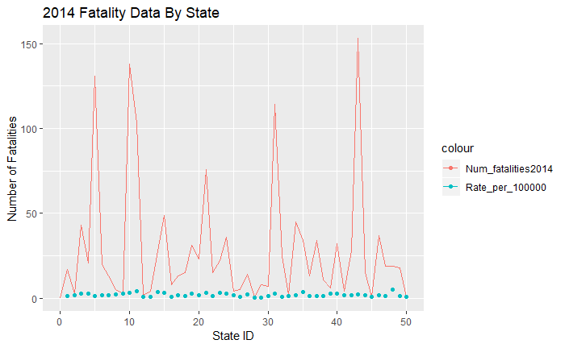

```r
# Layered graph
Graph_1 <-
  ggplot() +
  geom_line(data = All_data, aes(State_num, Num_fatalities2014, color = "Num_fatalities2014")) +
  geom_point(data = fed_data, aes(State_num, Rate_per_100000, color = "Rate_per_100000")) +
  xlab("State ID") +
  ylab("Number of Fatalities") +
  ggtitle("2014 Fatality Data By State")
plot(Graph_1)
```

```r
NA
```

## Graph 2

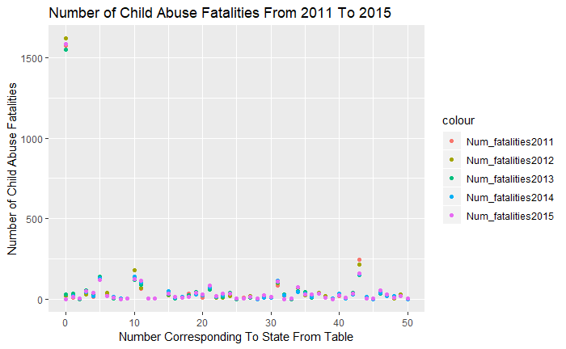

```r
# Multiple variables graph
Graph_2 <-
  All_data %>%
  ggplot() +
  geom_point(aes(x = State_num, y = Num_fatalities2011, color = "Num_fatalities2011")) +
  geom_point(aes(x = State_num, y = Num_fatalities2012, color = "Num_fatalities2012")) +
  geom_point(aes(x = State_num, y = Num_fatalities2013, color = "Num_fatalities2013")) +
  geom_point(aes(x = State_num, y = Num_fatalities2014, color = "Num_fatalities2014")) +
  geom_point(aes(x = State_num, y = Num_fatalities2015, color = "Num_fatalities2015")) +
  ggtitle("Number of Child Abuse Fatalities From 2011 To 2015") +
  xlab("Number Corresponding To State From Table") +
  ylab("Number of Child Abuse Fatalities")
plot(Graph_2)
```

## Graph 3

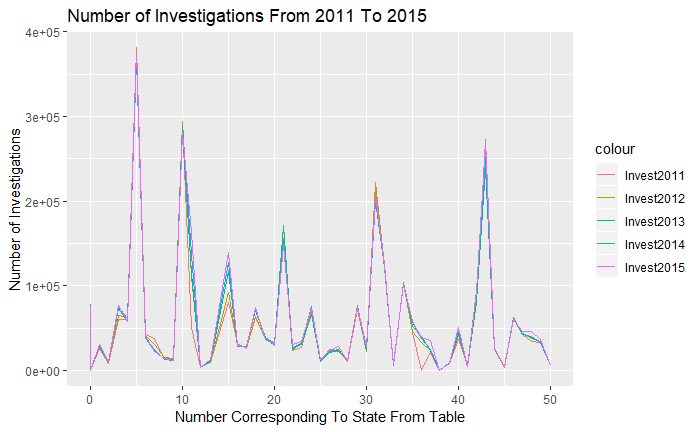

```r
# Multiple variables graph
Graph_3 <-
  All_data %>%
  ggplot() +
  geom_line(aes(State_num, Invest2011, color = "Invest2011")) +
  geom_line(aes(State_num, Invest2012, color = "Invest2012")) +
  geom_line(aes(State_num, Invest2013, color = "Invest2013")) +
  geom_line(aes(State_num, Invest2014, color = "Invest2014")) +
  geom_line(aes(State_num, Invest2015, color = "Invest2015")) +
  ggtitle("Number of Investigations From 2011 To 2015") +
  xlab("Number Corresponding To State From Table") +
  ylab("Number of Investigations")
plot(Graph_3)
```

Graph 3 shows the number of investigations in child abuse cases over 5 years. An interesting observation is that the same states that spiked in graph 1 - California, Florida, Michigan, New York, and Texas - also spike in this graph. 2015 seems to have the highest number of investigations most consistently.

## Graph 4

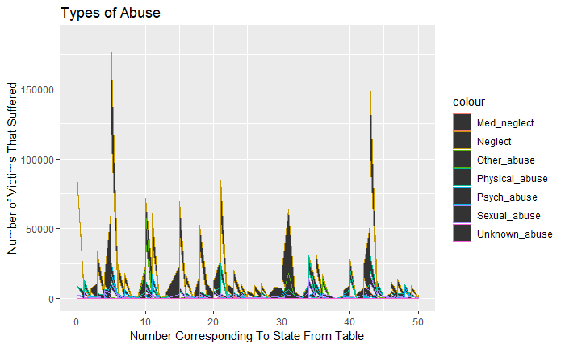

```r
# Multiple variables graph
Graph_4 <-
  All_data %>%
  ggplot() +
  geom_area(aes(State_num, Med_neglect, color = "Med_neglect")) +
  geom_area(aes(State_num, Neglect, color = "Neglect")) +
  geom_area(aes(State_num, Other_abuse, color = "Other_abuse")) +
  geom_area(aes(State_num, Physical_abuse, color = "Physical_abuse")) +
  geom_area(aes(State_num, Psych_abuse, color = "Psych_abuse")) +
  geom_area(aes(State_num, Sexual_abuse, color = "Sexual_abuse")) +
  geom_area(aes(State_num, Unknown_abuse, color = "Unknown_abuse")) +
  ggtitle("Types of Abuse") +
  xlab("Number Corresponding To State From Table") +
  ylab("Number of Victims That Suffered")
plot(Graph_4)
```

# Article on Child Abuse

https://www.nspcc.org.uk/what-we-do/childrens-stories-about-abuse/

This website provides different childs’ abuse stories. We have gathered a collection of 5 abuse stories compiled into a word document

```r
# Input text for analysis
Stories <-
  read.delim("Child abuse stories.txt", header = FALSE, fill = TRUE)
```

```
EOF within quoted string
```

```r
# Note it is being stored as a data frame of length 1
str(Stories)
```

```
'data.frame':   33 obs. of  1 variable:
 $ V1: Factor w/ 33 levels "“I grew up in a loving home with a happy childhood. I’d never witnessed domestic abuse or understood how damaging it was.",..: 25 1 10 33 4 32 18 5 3 28 ...
```

```r
length(Stories)
```

```
[1] 1
```

```r
# str_replace returns a character vector
Stories  <-
  Stories$V1 %>%
  str_replace_all("(\x92)+", "'") %>%
  str_replace_all("(\x93)+", "'")
str(Stories)
```

```
 chr [1:33] "Margaret's Story" ...
```

```r
length(Stories)
```

```
[1] 33
```

```r
# Subset Margaret's story
margaret_story <-
  data.frame(Stories[c(2:14)]) %>%
  mutate(text = Stories.c.2.14..) %>%
  select(- Stories.c.2.14..)
head(margaret_story)
```

|  | text |
| --- | --- |
| 1 | 'I grew up in a loving home with a happy childhood. I'd never witnessed domestic abuse or understood how damaging it was. |
| 2 | I first met Tony* when I was in my 20s. He was senior to me in the office, good looking and gave me lots of attention. |
| 3 | We started dating and I was really happy. But soon I started to see a more controlling and manipulative side to him. Tony didn't like me wearing certain clothes or seeing my friends. He'd ask me to sp… |
| 4 | After we got married he seemed to change. He became emotionally and psychologically abusive, threatening and belittling me. After I had my son Marcus*, he raped me for the first time. I blamed myself.… |
| 5 | Tony constantly accused me of having affairs, would shout and scream in my face in front of the children and would play mind games, making me feel guilty. 8 years into our marriage he started being ph… |
| 6 | I would defend him to my family. I would plead with the children to keep quiet and be good, even though they were beautifully behaved. I felt constantly condemned and my self-esteem was really low. |

```r
# unnest_tokens expects a character vector
text <-
  margaret_story$text %>%
  as.character()
# Create a data frame
text_df <-
  data_frame(line = 1:13, text = text)
text_df
```

| line | text |
| --- | --- |
| 1 | 'I grew up in a loving home with a happy childhood. I'd never witnessed domestic abuse or understood how damaging it was. |
| 2 | I first met Tony* when I was in my 20s. He was senior to me in the office, good looking and gave me lots of attention. |
| 3 | We started dating and I was really happy. But soon I started to see a more controlling and manipulative side to him. Tony didn't like me wearing certain clothes or seeing my friends. He'd ask me to sp… |
| 4 | After we got married he seemed to change. He became emotionally and psychologically abusive, threatening and belittling me. After I had my son Marcus*, he raped me for the first time. I blamed myself.… |
| 5 | Tony constantly accused me of having affairs, would shout and scream in my face in front of the children and would play mind games, making me feel guilty. 8 years into our marriage he started being ph… |
| 6 | I would defend him to my family. I would plead with the children to keep quiet and be good, even though they were beautifully behaved. I felt constantly condemned and my self-esteem was really low. |
| 7 | As the children got older Tony started being abusive towards them too. He would shout and beat them with belts and shoes. He would punish them when I wasn't in the house so I couldn't intervene. Whene… |
| 8 | After living with Tony for 12 years I finally snapped. We were in the kitchen and he trapped me against a unit. I threw down the food I was preparing and slapped him in the face. Before I knew it, he … |
| 9 | That night, after Tony had left for work I called the police. I was afraid of giving a statement but I wanted someone to know what was going on. Eventually, the children and I were taken to a safe hou… |
| 10 | I was worried about the violence the children had seen and how it might affect them. Both children were sullen, and weren't very good at articulating their feelings. They were very obedient and didn't… |

[output cut: 3 more lines]

```r
margaret_story_analysis <-
  text_df %>%
  unnest_tokens(word, text)
```

Throughout the past few code chunks, we have cleaned up the text document that contains stories about child abuse and chose one story in particular- Margaret. Her story relays to sexual abuse and how she worries her children will react to their abusive father later in life. In the next section of code, we will see which words are most prominent throughout the story and if they can provide any more insight into her story.

#### Token Frequency

```r
margaret_story_analysis %>%
  count(word, sort = TRUE)
```

| word | n |
| --- | --- |
| and | 36 |
| i | 30 |
| the | 24 |
| to | 23 |
| he | 18 |
| in | 14 |
| a | 13 |
| me | 12 |
| were | 12 |
| was | 11 |

[output cut: 312 more lines]

```r
# Load stop word list
data("stop_words")
head(stop_words)
```

| word | lexicon |
| --- | --- |
| a | SMART |
| a's | SMART |
| able | SMART |
| about | SMART |
| above | SMART |
| according | SMART |

```r
tail(stop_words)
```

| word | lexicon |
| --- | --- |
| you | onix |
| young | onix |
| younger | onix |
| youngest | onix |
| your | onix |
| yours | onix |

```r
margaret_story_analysis <-
  margaret_story_analysis %>%
  filter(!(word %in% stop_words$word))
margaret_story_analysis %>%
  count(word, sort = TRUE)
```

| word | n |
| --- | --- |
| children | 9 |
| tony | 7 |
| started | 5 |
| domestic | 4 |
| happy | 4 |
| house | 4 |
| abuse | 3 |
| abusive | 3 |
| finally | 3 |
| marcus | 3 |

[output cut: 160 more lines]

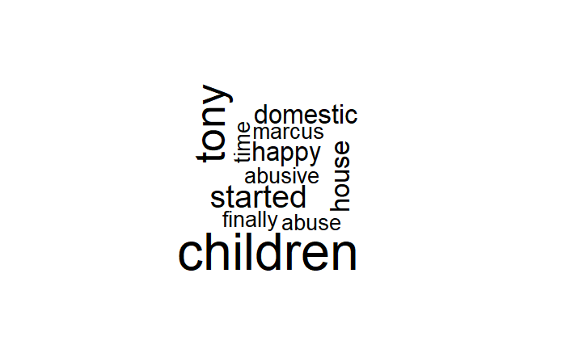

```r
margaret_story_analysis %>%
  filter(!(word %in% stop_words$word)) %>%
  count(word) %>%
  with(., wordcloud(word, n, max.words = 45))
```

This wordcloud shows some of the words that occured the most in Margaret’s story. It is not surprising to see words such as “children”, “abuse”, and “abusive” show up in this context. But is there a way to see how many negative words were in the story? Refer to the following code.

```r
data("sentiments")
head(sentiments, 10)
```

| word | sentiment | lexicon | score |
| --- | --- | --- | --- |
| abacus | trust | nrc | NA |
| abandon | fear | nrc | NA |
| abandon | negative | nrc | NA |
| abandon | sadness | nrc | NA |
| abandoned | anger | nrc | NA |
| abandoned | fear | nrc | NA |
| abandoned | negative | nrc | NA |
| abandoned | sadness | nrc | NA |
| abandonment | anger | nrc | NA |
| abandonment | fear | nrc | NA |

```r
tail(sentiments, 10)
```

| word | sentiment | lexicon | score |
| --- | --- | --- | --- |
| putative | superfluous | loughran | NA |
| recharacterization | superfluous | loughran | NA |
| redetermination | superfluous | loughran | NA |
| redetermined | superfluous | loughran | NA |
| stratum | superfluous | loughran | NA |
| superannuation | superfluous | loughran | NA |
| theses | superfluous | loughran | NA |
| ubiquitous | superfluous | loughran | NA |
| wheresoever | superfluous | loughran | NA |
| whilst | superfluous | loughran | NA |

```r
get_sentiments("nrc") %>%
  group_by(sentiment) %>%
  summarise(N= n()) %>%
  arrange(desc(N))
```

| sentiment | N |
| --- | --- |
| negative | 3324 |
| positive | 2312 |
| fear | 1476 |
| anger | 1247 |
| trust | 1231 |
| sadness | 1191 |
| disgust | 1058 |
| anticipation | 839 |
| joy | 689 |
| surprise | 534 |

#### Sentiment Analysis on Margaret’s Story

```r
nrc_fear <-
  get_sentiments("nrc") %>%
  filter(sentiment == "fear")
margaret_story_analysis %>%
  inner_join(nrc_fear) %>%
  count(word, sort = TRUE)
```

| word | n |
| --- | --- |
| abuse | 3 |
| change | 2 |
| violence | 2 |
| accused | 1 |
| afraid | 1 |
| awful | 1 |
| cross | 1 |
| dart | 1 |
| defend | 1 |
| lash | 1 |

[output cut: 5 more lines]